# About Dataset

salaries dataset generally provides information about the employees of an organization in relation to their compensation. It typically includes details such as how much each employee is paid (their salary), their job titles, the departments they work in, and possibly additional information like their level of experience, education, and employment history within the organization.

# Features

- 'Id'
- 'EmployeeName'
- 'JobTitle'
- 'BasePay'
- 'OvertimePay'
- 'OtherPay'
- 'Benefits'
- 'TotalPay' -> salary
- 'TotalPayBenefits'
- 'Year'
- 'Notes'
- 'Agency'
- 'Status'

# Tasks

1. **Basic Data Exploration**: Identify the number of rows and columns in the dataset, determine the data types of each column, and check for missing values in each column.
2. **Descriptive Statistics**: Calculate basic statistics mean, median, mode, minimum, and maximum salary, determine the range of salaries, and find the standard deviation.
3. **Data Cleaning**: Handle missing data by suitable method with explain why you use it.
4. **Basic Data Visualization**: Create histograms or bar charts to visualize the distribution of salaries, and use pie charts to represent the proportion of employees in different departments.
5. **Grouped Analysis**: Group the data by one or more columns and calculate summary statistics for each group, and compare the average salaries across different groups.
6. **Simple Correlation Analysis**: Identify any correlation between salary and another numerical column, and plot a scatter plot to visualize the relationship.
7. **Summary of Insights**: Write a brief report summarizing the findings and insights from the analyses.

# Very Important Note

There is no fixed or singular solution for this assignment, so if anything is not clear, please do what you understand and provide an explanation.

```python
import pandas as pd
import numpy as np
import matplotlib.pyplot as plt
%matplotlib inline

# Load your dataset
df = pd.read_csv('Salaries.csv')
df.head()
```

|  | Id | EmployeeName | JobTitle | BasePay | OvertimePay | OtherPay | Benefits | TotalPay | TotalPayBenefits | Year | Notes | Agency | Status |
| --- | --- | --- | --- | --- | --- | --- | --- | --- | --- | --- | --- | --- | --- |
| 0 | 1 | NATHANIEL FORD | GENERAL MANAGER-METROPOLITAN TRANSIT AUTHORITY | 167411.18 | 0.00 | 400184.25 | NaN | 567595.43 | 567595.43 | 2011 | NaN | San Francisco | NaN |
| 1 | 2 | GARY JIMENEZ | CAPTAIN III (POLICE DEPARTMENT) | 155966.02 | 245131.88 | 137811.38 | NaN | 538909.28 | 538909.28 | 2011 | NaN | San Francisco | NaN |
| 2 | 3 | ALBERT PARDINI | CAPTAIN III (POLICE DEPARTMENT) | 212739.13 | 106088.18 | 16452.60 | NaN | 335279.91 | 335279.91 | 2011 | NaN | San Francisco | NaN |
| 3 | 4 | CHRISTOPHER CHONG | WIRE ROPE CABLE MAINTENANCE MECHANIC | 77916.00 | 56120.71 | 198306.90 | NaN | 332343.61 | 332343.61 | 2011 | NaN | San Francisco | NaN |
| 4 | 5 | PATRICK GARDNER | DEPUTY CHIEF OF DEPARTMENT,(FIRE DEPARTMENT) | 134401.60 | 9737.00 | 182234.59 | NaN | 326373.19 | 326373.19 | 2011 | NaN | San Francisco | NaN |

```python
df.columns
```

```
Index(['Id', 'EmployeeName', 'JobTitle', 'BasePay', 'OvertimePay', 'OtherPay',
       'Benefits', 'TotalPay', 'TotalPayBenefits', 'Year', 'Notes', 'Agency',
       'Status'],
      dtype='object')
```

# *******Solution Starting Point*******

## **1. Basic Data Exploration:**

Okay let's get some Info about our Data...

```python
df.info()
```

```
<class 'pandas.core.frame.DataFrame'>
RangeIndex: 148654 entries, 0 to 148653
Data columns (total 13 columns):
 #   Column            Non-Null Count   Dtype
---  ------            --------------   -----
 0   Id                148654 non-null  int64
 1   EmployeeName      148654 non-null  object
 2   JobTitle          148654 non-null  object
 3   BasePay           148045 non-null  float64
 4   OvertimePay       148650 non-null  float64
 5   OtherPay          148650 non-null  float64
 6   Benefits          112491 non-null  float64
 7   TotalPay          148654 non-null  float64
 8   TotalPayBenefits  148654 non-null  float64
 9   Year              148654 non-null  int64
 10  Notes             0 non-null       float64
 11  Agency            148654 non-null  object
 12  Status            0 non-null       float64
dtypes: float64(8), int64(2), object(3)
memory usage: 14.7+ MB
```

```python
# Just to be sure 😅
print("EmployeeName:", type(df.EmployeeName[0]))
print("JobTitle:", type(df.JobTitle[0]))
print("Agency:", type(df.Agency[0]))
```

```
EmployeeName: <class 'str'>
JobTitle: <class 'str'>
Agency: <class 'str'>
```

```python
# Getting Null Values
df.isnull().sum()
```

```
Id                       0
EmployeeName             0
JobTitle                 0
BasePay                609
OvertimePay              4
OtherPay                 4
Benefits             36163
TotalPay                 0
TotalPayBenefits         0
Year                     0
Notes               148654
Agency                   0
Status              148654
dtype: int64
```

So we found that:

- **Number of Rows:** 148654
- **Number of Columns:** 13
- **The data types of each column:**

  We have **Three Categorical Columns**, and **Ten Numerical Columns**

  We have *Eight* **Float** columns, *Two* **Integer** columns, and *Three* **String** columns.

  | # | Column | Type |
  | --- | --- | --- |
  | 1 | Id | int64 |
  | 2 | EmployeeName | string |
  | 3 | JobTitle | string |
  | 4 | BasePay | float64 |
  | 5 | OvertimePay | float64 |
  | 6 | OtherPay | float64 |
  | 7 | Benefits | float64 |
  | 8 | TotalPay | float64 |
  | 9 | TotalPayBenefits | float64 |
  | 10 | Year | int64 |
  | 11 | Notes | float64 |
  | 12 | Agency | string |
  | 13 | Status | float64 |

- **Missing values in each column:** - **Two** totally empty columns (*Notes & Status*). - **Seven** totally filled columns (*Id, EmployeeName, JobTitle, TotalPay, TotalPayBenefits, Year & Agency*). - **Two** columns missing only four entries (*OvertimePay, OtherPay*). - **One** Column with 0.4% (609 entries) of its values are null (*BasePay*). - **One** Column with 24.3% (36163 entries) of its values are null (*Benefits*).

## **2. Descriptive Statistics:**

Okay now let's have some insights...

```python
# Getting Basic Insights
df.describe(include="all")
```

|  | Id | EmployeeName | JobTitle | BasePay | OvertimePay | OtherPay | Benefits | TotalPay | TotalPayBenefits | Year | Notes | Agency | Status |
| --- | --- | --- | --- | --- | --- | --- | --- | --- | --- | --- | --- | --- | --- |
| count | 148654.000000 | 148654 | 148654 | 148045.000000 | 148650.000000 | 148650.000000 | 112491.000000 | 148654.000000 | 148654.000000 | 148654.000000 | 0.0 | 148654 | 0.0 |
| unique | NaN | 110811 | 2159 | NaN | NaN | NaN | NaN | NaN | NaN | NaN | NaN | 1 | NaN |
| top | NaN | Kevin Lee | Transit Operator | NaN | NaN | NaN | NaN | NaN | NaN | NaN | NaN | San Francisco | NaN |
| freq | NaN | 13 | 7036 | NaN | NaN | NaN | NaN | NaN | NaN | NaN | NaN | 148654 | NaN |
| mean | 74327.500000 | NaN | NaN | 66325.448840 | 5066.059886 | 3648.767297 | 25007.893151 | 74768.321972 | 93692.554811 | 2012.522643 | NaN | NaN | NaN |
| std | 42912.857795 | NaN | NaN | 42764.635495 | 11454.380559 | 8056.601866 | 15402.215858 | 50517.005274 | 62793.533483 | 1.117538 | NaN | NaN | NaN |
| min | 1.000000 | NaN | NaN | -166.010000 | -0.010000 | -7058.590000 | -33.890000 | -618.130000 | -618.130000 | 2011.000000 | NaN | NaN | NaN |
| 25% | 37164.250000 | NaN | NaN | 33588.200000 | 0.000000 | 0.000000 | 11535.395000 | 36168.995000 | 44065.650000 | 2012.000000 | NaN | NaN | NaN |
| 50% | 74327.500000 | NaN | NaN | 65007.450000 | 0.000000 | 811.270000 | 28628.620000 | 71426.610000 | 92404.090000 | 2013.000000 | NaN | NaN | NaN |
| 75% | 111490.750000 | NaN | NaN | 94691.050000 | 4658.175000 | 4236.065000 | 35566.855000 | 105839.135000 | 132876.450000 | 2014.000000 | NaN | NaN | NaN |
| max | 148654.000000 | NaN | NaN | 319275.010000 | 245131.880000 | 400184.250000 | 96570.660000 | 567595.430000 | 567595.430000 | 2014.000000 | NaN | NaN | NaN |

```python
# Getting Range
df.max(numeric_only=True) - df.min(numeric_only=True)
```

```
Id                  148653.00
BasePay             319441.02
OvertimePay         245131.89
OtherPay            407242.84
Benefits             96604.55
TotalPay            568213.56
TotalPayBenefits    568213.56
Year                     3.00
Notes                     NaN
Status                    NaN
dtype: float64
```

```python
# Getting Median
df.median(numeric_only=True)
```

```
Id                  74327.50
BasePay             65007.45
OvertimePay             0.00
OtherPay              811.27
Benefits            28628.62
TotalPay            71426.61
TotalPayBenefits    92404.09
Year                 2013.00
Notes                    NaN
Status                   NaN
dtype: float64
```

```python
# Getting Mode "1st"
df.mode().iloc[0]
```

```
Id                                 1
EmployeeName               Kevin Lee
JobTitle            Transit Operator
BasePay                          0.0
OvertimePay                      0.0
OtherPay                         0.0
Benefits                         0.0
TotalPay                         0.0
TotalPayBenefits             7959.18
Year                          2014.0
Notes                            NaN
Agency                 San Francisco
Status                           NaN
Name: 0, dtype: object
```

```python
# Getting Standard Deviation
df.std(numeric_only=True)
```

```
Id                  42912.857795
BasePay             42764.635495
OvertimePay         11454.380559
OtherPay             8056.601866
Benefits            15402.215858
TotalPay            50517.005274
TotalPayBenefits    62793.533483
Year                    1.117538
Notes                        NaN
Status                       NaN
dtype: float64
```

So here is a summry of the Basic Statstics we found:

| # | Column | Mean | Median | Mode [1st] | Minimum | Maximum | Range | Standard Deviation |
| --- | --- | --- | --- | --- | --- | --- | --- | --- |
| 1 | Id | 74327.50 | 74327.50 | 1 | 1.00 | 148654.00 | 148653.00 | 42912.86 |
| 2 | EmployeeName | --- | --- | Kevin Lee | --- | --- | --- | --- |
| 3 | JobTitle | --- | --- | Transit Operator | --- | --- | --- | --- |
| 4 | BasePay | 66325.45 | 65007.45 | 0.0 | -166.01 | 319275.01 | 319441.02 | 42764.63 |
| 5 | OvertimePay | 5066.06 | 0.00 | 0.0 | -0.01 | 245131.88 | 245131.89 | 11454.38 |
| 6 | OtherPay | 3648.77 | 811.27 | 0.0 | -7058.59 | 400184.25 | 407242.84 | 8056.60 |
| 7 | Benefits | 25007.89 | 28628.62 | 0.0 | -33.89 | 96570.66 | 96604.55 | 15402.22 |
| 8 | TotalPay | 74768.32 | 71426.61 | 0.0 | -618.13 | 567595.43 | 568213.56 | 50517.00 |
| 9 | TotalPayBenefits | 93692.55 | 92404.09 | 7959.18 | -618.13 | 567595.43 | 568213.56 | 62793.53 |
| 10 | Year | 2012.52 | 2013.00 | 2014.00 | 2011.00 | 2014.00 | 3.00 | 1.12 |
| 11 | Notes | --- | --- | --- | --- | --- | --- | --- |
| 12 | Agency | --- | --- | San Francisco | --- | --- | --- | --- |
| 13 | Status | --- | --- | --- | --- | --- | --- | --- |

We will see how these basic statistics change after making our cleaning.

## **3. Data Cleaning:**

Okay now let's Clean our Data. 🧹

First of all, we have two empty columns (Notes & Status), we could investigate later why that happened, but for now, let's just drop them.

```python
df_cleaned = df.drop(columns=['Notes', 'Status'])
```

Also All Agency Column's Values contains The Same Value **"San Francisco"** so It won't be of great use for our analysis and may slows down the preformance, so let's drop it and keep that info as a side note. that every body is from a single Agency named **"San Francisco"**

```python
df.Agency.unique()
```

```
array(['San Francisco'], dtype=object)
```

```python
df_cleaned = df_cleaned.drop(columns=["Agency"])
```

From our basic statistics we have seen that there are negative values in columns like (BasePay, OvertimePay, OtherPay, Benefits, TotalPay) which may be acceptable in some scenarios but The TotalPayBenefits Column can not be less than or equal to Zero, Unless the organization has some kind of Slavery regime, I can't think of an Employee working there and have to pay to the Organization for his work, So maybe that is entry mistake or something but I will be more comfortable if I dropped these rows if they are not of a significant count.

```python
len(df_cleaned[df_cleaned.TotalPayBenefits <= 0])
```

```
34
```

Okay they just 34 rows we can drop them for now, and we can then later investigate who are those poor Employees.

```python
len(df_cleaned)
```

```
148654
```

```python
df_cleaned = df_cleaned[df_cleaned.TotalPayBenefits > 0]
```

```python
len(df_cleaned)
```

```
148620
```

Okay let's check our null status now.

```python
df_cleaned.isnull().sum()
```

```
Id                      0
EmployeeName            0
JobTitle                0
BasePay               602
OvertimePay             0
OtherPay                0
Benefits            36156
TotalPay                0
TotalPayBenefits        0
Year                    0
dtype: int64
```

```python
df[df.OvertimePay.isnull() | df.OtherPay.isnull()]
```

|  | Id | EmployeeName | JobTitle | BasePay | OvertimePay | OtherPay | Benefits | TotalPay | TotalPayBenefits | Year | Notes | Agency | Status |
| --- | --- | --- | --- | --- | --- | --- | --- | --- | --- | --- | --- | --- | --- |
| 148646 | 148647 | Not provided | Not provided | NaN | NaN | NaN | NaN | 0.0 | 0.0 | 2014 | NaN | San Francisco | NaN |
| 148650 | 148651 | Not provided | Not provided | NaN | NaN | NaN | NaN | 0.0 | 0.0 | 2014 | NaN | San Francisco | NaN |
| 148651 | 148652 | Not provided | Not provided | NaN | NaN | NaN | NaN | 0.0 | 0.0 | 2014 | NaN | San Francisco | NaN |
| 148652 | 148653 | Not provided | Not provided | NaN | NaN | NaN | NaN | 0.0 | 0.0 | 2014 | NaN | San Francisco | NaN |

The 4 null values in (*OvertimePay & OtherPay*) Columns have been gone, and from what I see in those 4 rows I think that was a good decision, and we are left with null values at (*BasePay & Benefits*) Columns.

Okay, So from our Data we can see that the **TotalPay** is the Sum of [*Basepay, OvertimePay, OtherPay*], while the **TotalPayBenefits** adds the *Benefits* to the *TotalPay*, so let's check if that calculation is correct in each row. to decide if we gonna fill the null values with Zeros or a missing value.

```python
# Checking TotalPay
df_cleaned['TotalPay_chk'] = df_cleaned.loc[:, (
    'BasePay', 'OvertimePay', 'OtherPay'
)].sum(axis=1)
```

```python
df_cleaned[
    df_cleaned.TotalPay.round(2) != df_cleaned.TotalPay_chk.round(2)
][['TotalPay', 'TotalPay_chk']].count()
```

```
TotalPay        0
TotalPay_chk    0
dtype: int64
```

```python
# Checking TotalPayBenefits
df_cleaned['TotalPayBenefits_chk'] = df_cleaned.loc[:, (
    'BasePay', 'OvertimePay', 'OtherPay', 'Benefits'
)].sum(axis=1)
```

```python
df_cleaned[
    df_cleaned.TotalPayBenefits.round(2) != df_cleaned.TotalPayBenefits_chk.round(2)
][['TotalPayBenefits', 'TotalPayBenefits_chk']].count()
```

```
TotalPayBenefits        0
TotalPayBenefits_chk    0
dtype: int64
```

We confirmed that the Values in *TotalPay* and *TotalPayBenefits* are summed correctly with the hypothesis of null values being Zeros, So we can safely fill the null values in (*BasePay & Benefits*) Columns with Zeros.

```python
df_cleaned = df_cleaned.drop(columns=['TotalPay_chk', 'TotalPayBenefits_chk'])
df_cleaned.fillna(0, inplace=True)
```

```python
df_cleaned.isnull().sum()
```

```
Id                  0
EmployeeName        0
JobTitle            0
BasePay             0
OvertimePay         0
OtherPay            0
Benefits            0
TotalPay            0
TotalPayBenefits    0
Year                0
dtype: int64
```

Let's check if there is any duplicates.

```python
cols = list(df_cleaned.columns)  # get all columns names in form of list
df_cleaned[df_cleaned.duplicated(subset=cols[1:])].count()  # without Id col
```

```
Id                  0
EmployeeName        0
JobTitle            0
BasePay             0
OvertimePay         0
OtherPay            0
Benefits            0
TotalPay            0
TotalPayBenefits    0
Year                0
dtype: int64
```

Great, there is no Duplicate rows.

## **4. Basic Data Visualization**

Let's first redo our Basic Statistics state after cleaning the data.

```python
df_cleaned.describe(include='all')
```

|  | Id | EmployeeName | JobTitle | BasePay | OvertimePay | OtherPay | Benefits | TotalPay | TotalPayBenefits | Year |
| --- | --- | --- | --- | --- | --- | --- | --- | --- | --- | --- |
| count | 148620.000000 | 148620 | 148620 | 148620.000000 | 148620.000000 | 148620.000000 | 148620.000000 | 148620.000000 | 148620.000000 | 148620.000000 |
| unique | NaN | 110801 | 2158 | NaN | NaN | NaN | NaN | NaN | NaN | NaN |
| top | NaN | Kevin Lee | Transit Operator | NaN | NaN | NaN | NaN | NaN | NaN | NaN |
| freq | NaN | 13 | 7036 | NaN | NaN | NaN | NaN | NaN | NaN | NaN |
| mean | 74313.539140 | NaN | NaN | 66068.840490 | 5067.082507 | 3649.507985 | 18928.562463 | 74785.430982 | 93713.993445 | 2012.522386 |
| std | 42904.989939 | NaN | NaN | 42879.976478 | 11455.310413 | 8057.246124 | 17164.855593 | 50510.115978 | 62784.714471 | 1.117458 |
| min | 1.000000 | NaN | NaN | -166.010000 | -0.010000 | -7058.590000 | -13.800000 | 0.000000 | 0.300000 | 2011.000000 |
| 25% | 37158.750000 | NaN | NaN | 32843.760000 | 0.000000 | 0.000000 | 0.000000 | 36198.150000 | 44132.715000 | 2012.000000 |
| 50% | 74313.500000 | NaN | NaN | 64873.275000 | 0.000000 | 812.425000 | 23237.620000 | 71433.495000 | 92419.380000 | 2013.000000 |
| 75% | 111471.250000 | NaN | NaN | 94611.010000 | 4659.260000 | 4237.905000 | 33470.330000 | 105849.575000 | 132887.897500 | 2014.000000 |
| max | 148626.000000 | NaN | NaN | 319275.010000 | 245131.880000 | 400184.250000 | 96570.660000 | 567595.430000 | 567595.430000 | 2014.000000 |

```python
# Getting Range
df_cleaned.max(numeric_only=True) - df_cleaned.min(numeric_only=True)
```

```
Id                  148625.00
BasePay             319441.02
OvertimePay         245131.89
OtherPay            407242.84
Benefits             96584.46
TotalPay            567595.43
TotalPayBenefits    567595.13
Year                     3.00
dtype: float64
```

```python
# Getting Median
df_cleaned.median(numeric_only=True)
```

```
Id                  74313.500
BasePay             64873.275
OvertimePay             0.000
OtherPay              812.425
Benefits            23237.620
TotalPay            71433.495
TotalPayBenefits    92419.380
Year                 2013.000
dtype: float64
```

```python
# Getting Mode "1st"
df_cleaned.mode().iloc[0]
```

```
Id                                 1
EmployeeName               Kevin Lee
JobTitle            Transit Operator
BasePay                          0.0
OvertimePay                      0.0
OtherPay                         0.0
Benefits                         0.0
TotalPay                         0.0
TotalPayBenefits             7959.18
Year                          2014.0
Name: 0, dtype: object
```

```python
# Getting Standard Deviation
df_cleaned.std(numeric_only=True)
```

```
Id                  42904.989939
BasePay             42879.976478
OvertimePay         11455.310413
OtherPay             8057.246124
Benefits            17164.855593
TotalPay            50510.115978
TotalPayBenefits    62784.714471
Year                    1.117458
dtype: float64
```

So here is a summry of the new Basic Statstics after data cleaning:

| # | Column | Mean | Median | Mode [1st] | Minimum | Maximum | Range | Standard Deviation |
| --- | --- | --- | --- | --- | --- | --- | --- | --- |
| 1 | Id | 74313.54 | 74313.50 | 1 | 1.00 | 148626.00 | 148625.00 | 42904.99 |
| 2 | EmployeeName | --- | --- | Kevin Lee | --- | --- | --- | --- |
| 3 | JobTitle | --- | --- | Transit Operator | --- | --- | --- | --- |
| 4 | BasePay | 66068.84 | 64873.27 | 0.0 | -166.01 | 319275.01 | 319441.02 | 42879.98 |
| 5 | OvertimePay | 5067.08 | 0.00 | 0.0 | -0.01 | 245131.88 | 245131.89 | 11455.31 |
| 6 | OtherPay | 3649.51 | 812.42 | 0.0 | -7058.59 | 400184.25 | 407242.84 | 8057.25 |
| 7 | Benefits | 18928.56 | 23237.62 | 0.0 | -13.80 | 96570.66 | 96584.46 | 17164.86 |
| 8 | TotalPay | 74785.43 | 71433.49 | 0.0 | 0.00 | 567595.43 | 567595.43 | 50510.12 |
| 9 | TotalPayBenefits | 93713.99 | 92419.38 | 7959.18 | 0.30 | 567595.43 | 567595.13 | 62784.71 |
| 10 | Year | 2012.52 | 2013.00 | 2014.0 | 2011.00 | 2014.00 | 3.00 | 1.12 |

Let's now have some Fun 😎

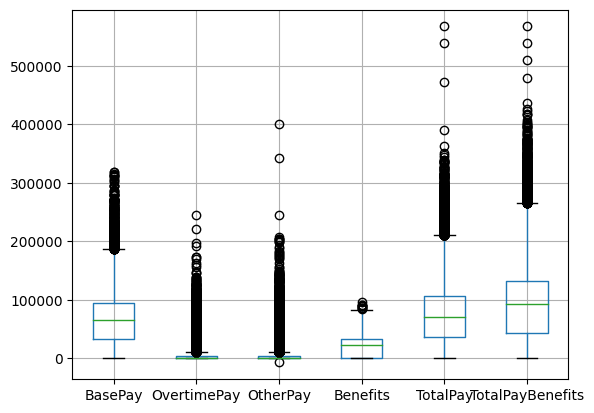

```python
df_cleaned.boxplot(column=cols[3:9])  # Salary related columns
```

As any Normal Orgnization's Salaries, our Data has outliers and is [Skewed to te Right](https://alanarnholt.github.io/PDS-Bookdown2/skewed-right-distributions.html) 🤑.

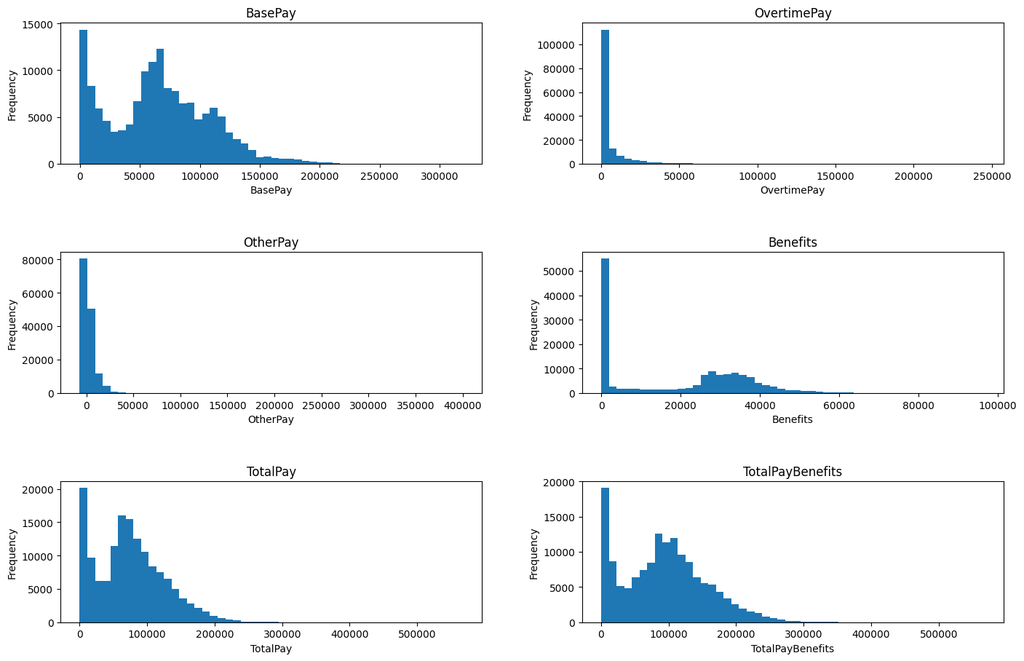

```python
columns_to_plot = cols[3:9]

num_cols = 2
num_rows = (len(
    columns_to_plot
) + num_cols - 1) // num_cols  # Calculate number of rows needed for the grid

fig, axs = plt.subplots(
    num_rows, num_cols, figsize=(15, 10)
)  # Create subplots grid

plt.subplots_adjust(hspace=0.5, wspace=0.5)  # Add margin between subplots

for i, column in enumerate(columns_to_plot):
    row = i // num_cols
    col = i % num_cols
    axs[row, col].hist(df_cleaned[column], bins=50)
    axs[row, col].set_title(column)
    axs[row, col].set_xlabel(column)
    axs[row, col].set_ylabel('Frequency')

# Hide any unused subplots
for i in range(len(columns_to_plot), num_rows * num_cols):
    row = i // num_cols
    col = i % num_cols
    axs[row, col].axis('off')

plt.tight_layout(pad=4)
plt.show()
```

It feels like there is a mix between two types of models, I'll guess the higher concentration of the low Payments part of the curve is due to Freelancers or Part-Time Jobs, while the rest of the rest of the graph is due to Full-time Normal Jobs.

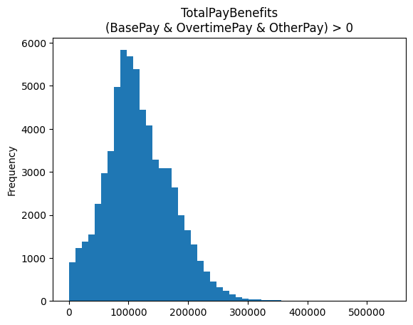

```python
df_cleaned[
    (df_cleaned.BasePay > 0)
    &
    (df_cleaned.OvertimePay > 0)
    &
    (df_cleaned.OtherPay > 0)
].TotalPayBenefits.plot.hist(
    bins=50,
    title="TotalPayBenefits\n(BasePay & OvertimePay & OtherPay) > 0"
);
```

It's a wild guess but we can target the Full-time jobs by filtering rows having no BasePay, OvertimePay, and OtherPay less than or equal to Zero.

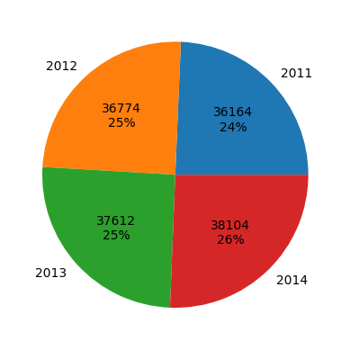

```python
def label_function(val):
    return f'{val / 100 * len(df):.0f}\n{val:.0f}%'

df_cleaned.groupby('Year').size().plot(kind='pie', autopct=label_function);
```

There is no big difference between the number of Employees between years, the difference between the biggest and the smallest is around 2%.

## **5. Grouped Analysis**

Let's group the Data by the Year Column.

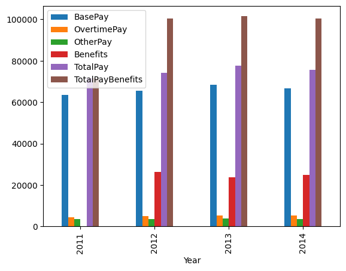

```python
df_cleaned.groupby('Year')[cols[3:9]].mean().plot(kind="bar");
```

```python
df_cleaned.groupby("Year")['Benefits'].aggregate([
    min,
    max,
    sum,
    'mean'
])
```

| Year | min | max | sum | mean |
| --- | --- | --- | --- | --- |
| 2011 | 0.0 | 0.00 | 0.000000e+00 | 0.000000 |
| 2012 | 0.0 | 84681.82 | 9.720918e+08 | 26439.966967 |
| 2013 | 0.0 | 86533.21 | 8.961163e+08 | 23830.978868 |
| 2014 | -13.8 | 96570.66 | 9.449548e+08 | 24805.219303 |

- There was a growth in Salaries Mean from 2011 to 2013, but then a decline after 2013.
- We can also see that they activated Benefits starting in 2012, there were no Benefits in 2011.

How do get paid the most BasePay each year?

```python
df_cleaned.loc[df_cleaned.groupby('Year')['BasePay'].idxmax()]\
 [['Year', 'EmployeeName', 'BasePay']]
```

|  | Year | EmployeeName | BasePay |
| --- | --- | --- | --- |
| 12 | 2011 | EDWARD HARRINGTON | 294580.02 |
| 36160 | 2012 | Gregory Suhr | 302578.00 |
| 72925 | 2013 | Gregory P Suhr | 319275.01 |
| 110532 | 2014 | Amy P Hart | 318835.49 |

Okay, I can see that the Chief of the Police gets the highest BasePay for Two years in a row.

```python
df_cleaned.loc[df_cleaned.groupby('Year')['TotalPay'].idxmax()]\
 [['Year', 'EmployeeName', 'JobTitle', 'TotalPay']]
```

|  | Year | EmployeeName | JobTitle | TotalPay |
| --- | --- | --- | --- | --- |
| 0 | 2011 | NATHANIEL FORD | GENERAL MANAGER-METROPOLITAN TRANSIT AUTHORITY | 567595.43 |
| 36159 | 2012 | Gary Altenberg | Lieutenant, Fire Suppression | 362844.66 |
| 72927 | 2013 | Samson Lai | Battalion Chief, Fire Suppress | 347102.32 |
| 110531 | 2014 | David Shinn | Deputy Chief 3 | 471952.64 |

```python
df_cleaned.loc[df_cleaned.groupby('Year')['Benefits'].idxmax()]\
 [['Year', 'EmployeeName', 'JobTitle', 'Benefits']]
```

|  | Year | EmployeeName | JobTitle | Benefits |
| --- | --- | --- | --- | --- |
| 0 | 2011 | NATHANIEL FORD | GENERAL MANAGER-METROPOLITAN TRANSIT AUTHORITY | 0.00 |
| 36164 | 2012 | Amy Hart | Dept Head V | 84681.82 |
| 72925 | 2013 | Gregory P Suhr | Chief of Police | 86533.21 |
| 110533 | 2014 | William J Coaker Jr. | Chief Investment Officer | 96570.66 |

```python
df_cleaned.loc[df_cleaned.groupby('Year')['TotalPayBenefits'].idxmax()]\
 [['Year', 'EmployeeName', 'JobTitle', 'TotalPayBenefits']]
```

|  | Year | EmployeeName | JobTitle | TotalPayBenefits |
| --- | --- | --- | --- | --- |
| 0 | 2011 | NATHANIEL FORD | GENERAL MANAGER-METROPOLITAN TRANSIT AUTHORITY | 567595.43 |
| 36159 | 2012 | Gary Altenberg | Lieutenant, Fire Suppression | 407274.78 |
| 72925 | 2013 | Gregory P Suhr | Chief of Police | 425815.28 |
| 110531 | 2014 | David Shinn | Deputy Chief 3 | 510732.68 |

So Jobs Containing Chief, Head, Manager or some kind of high position have the highest Pay and Benefits as Expected.

## **6. Simple Correlation Analysis**

What kind of relation between BasePay and Benefits?

```
Correlation between BasePay and Benefits = 0.65
```

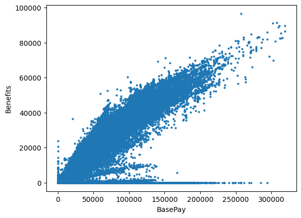

```python
corll = df_cleaned.BasePay.corr(df_cleaned.Benefits)
print(f"Correlation between BasePay and Benefits = {round(corll, 2)}\n")
df_cleaned.plot.scatter(x='BasePay', y='Benefits', s=4);
```

But to be fair we should remove 2011 rows when their was no Benefits yet.

```
Correlation between BasePay and Benefits = 0.92
```

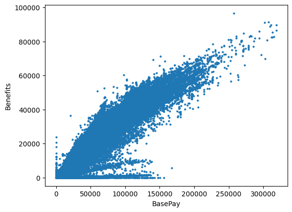

```python
df_no_2011 = df_cleaned.loc[df_cleaned.Year != 2011]

corll = df_no_2011.BasePay.corr(df_no_2011.Benefits)
print(f"Correlation between BasePay and Benefits = {round(corll, 2)}\n")
df_no_2011.plot.scatter(x='BasePay', y='Benefits', s=4);
```

There is a strong Positive Relationship between BasePay and Benefits.

What kind of relation between BasePay and TotalPay?

```
Correlation between BasePay and TotalPay = 0.95
```

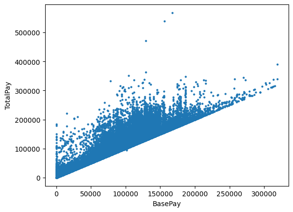

```python
corll = df_cleaned.BasePay.corr(df_cleaned.TotalPay)
print(f"Correlation between BasePay and TotalPay = {round(corll, 2)}\n")
df_cleaned.plot.scatter(x='BasePay', y='TotalPay', s=4);
```

There is a strong Positive Relationship between BasePay and TotalPay.

## **7. Summary of Insights:**

- Number of Rows: 148654
- Number of Columns: 13
- Data Consists of 3 Categorical Columns and 10 Numerical Columns.
- Data Consists of 8 Float columns, 2 Integer columns, and 3 String columns.
- Strangely there are Employees with negative salaries.
- Notes and Status Columns are empty.
- All the data belongs to a single Agency "San Francisco".
- Data has outliers and is Skewed to the Right.
- There is a great chance that the data is a mix between two types of models, which may be due to two different types of salaries Part-Time and Full-time Jobs.
- The number of Employees between years is almost the same.
- Jobs Titles Containing Chief, Head, Manager or some kind of high position have the highest Salaries.
- There was a growth in Salaries Mean from 2011 to 2013, but then a decline after 2013.
- The decision to add Benefits to Employees Salary was issued starting from 2012.
- The Value of BasePay has a strong positive direct effect on Both Benefits and TotalPay of the Employee.